# Risk Factor Analysis

## Outcome Variable

**Outcome Variable:** pers_wasted624

## Predictor Variables

**Intervention Variable:** ever_sstunted06

**Adjustment Set:**

unadjusted

## Stratifying Variables

The analysis was stratified on these variable(s):

- studyid
- country

## Data Summary

| studyid | country | ever_sstunted06 | pers_wasted624 | n_cell | n |
| --- | --- | --- | --- | --- | --- |
| ki0047075b-MAL-ED | BANGLADESH | 0 | 0 | 209 | 240 |
| ki0047075b-MAL-ED | BANGLADESH | 0 | 1 | 16 | 240 |
| ki0047075b-MAL-ED | BANGLADESH | 1 | 0 | 13 | 240 |
| ki0047075b-MAL-ED | BANGLADESH | 1 | 1 | 2 | 240 |
| ki0047075b-MAL-ED | BRAZIL | 0 | 0 | 190 | 202 |
| ki0047075b-MAL-ED | BRAZIL | 0 | 1 | 2 | 202 |
| ki0047075b-MAL-ED | BRAZIL | 1 | 0 | 10 | 202 |
| ki0047075b-MAL-ED | BRAZIL | 1 | 1 | 0 | 202 |
| ki0047075b-MAL-ED | INDIA | 0 | 0 | 193 | 234 |
| ki0047075b-MAL-ED | INDIA | 0 | 1 | 22 | 234 |
| ki0047075b-MAL-ED | INDIA | 1 | 0 | 13 | 234 |
| ki0047075b-MAL-ED | INDIA | 1 | 1 | 6 | 234 |
| ki0047075b-MAL-ED | NEPAL | 0 | 0 | 225 | 234 |
| ki0047075b-MAL-ED | NEPAL | 0 | 1 | 2 | 234 |
| ki0047075b-MAL-ED | NEPAL | 1 | 0 | 7 | 234 |
| ki0047075b-MAL-ED | NEPAL | 1 | 1 | 0 | 234 |
| ki0047075b-MAL-ED | PERU | 0 | 0 | 233 | 264 |
| ki0047075b-MAL-ED | PERU | 0 | 1 | 1 | 264 |
| ki0047075b-MAL-ED | PERU | 1 | 0 | 29 | 264 |
| ki0047075b-MAL-ED | PERU | 1 | 1 | 1 | 264 |
| ki0047075b-MAL-ED | SOUTH AFRICA | 0 | 0 | 231 | 258 |
| ki0047075b-MAL-ED | SOUTH AFRICA | 0 | 1 | 2 | 258 |
| ki0047075b-MAL-ED | SOUTH AFRICA | 1 | 0 | 25 | 258 |
| ki0047075b-MAL-ED | SOUTH AFRICA | 1 | 1 | 0 | 258 |
| ki0047075b-MAL-ED | TANZANIA, UNITED REPUBLIC OF | 0 | 0 | 213 | 244 |
| ki0047075b-MAL-ED | TANZANIA, UNITED REPUBLIC OF | 0 | 1 | 0 | 244 |
| ki0047075b-MAL-ED | TANZANIA, UNITED REPUBLIC OF | 1 | 0 | 31 | 244 |
| ki0047075b-MAL-ED | TANZANIA, UNITED REPUBLIC OF | 1 | 1 | 0 | 244 |
| ki1000107-Serrinha-VitA | BRAZIL | 0 | 0 | 10 | 11 |
| ki1000107-Serrinha-VitA | BRAZIL | 0 | 1 | 1 | 11 |

[output cut: 126 more lines]

The following strata were considered:

- studyid: ki0047075b-MAL-ED, country: BANGLADESH
- studyid: ki0047075b-MAL-ED, country: BRAZIL
- studyid: ki0047075b-MAL-ED, country: INDIA
- studyid: ki0047075b-MAL-ED, country: NEPAL
- studyid: ki0047075b-MAL-ED, country: PERU
- studyid: ki0047075b-MAL-ED, country: SOUTH AFRICA
- studyid: ki0047075b-MAL-ED, country: TANZANIA, UNITED REPUBLIC OF
- studyid: ki1000107-Serrinha-VitA, country: BRAZIL
- studyid: ki1000108-CMC-V-BCS-2002, country: INDIA
- studyid: ki1000108-IRC, country: INDIA
- studyid: ki1000109-EE, country: PAKISTAN
- studyid: ki1000109-ResPak, country: PAKISTAN
- studyid: ki1000304-VITAMIN-A, country: INDIA
- studyid: ki1000304b-SAS-CompFeed, country: INDIA
- studyid: ki1000304b-SAS-FoodSuppl, country: INDIA
- studyid: ki1017093-NIH-Birth, country: BANGLADESH
- studyid: ki1017093b-PROVIDE, country: BANGLADESH
- studyid: ki1017093c-NIH-Crypto, country: BANGLADESH
- studyid: ki1033518-iLiNS-DYAD-G, country: GHANA
- studyid: ki1066203-TanzaniaChild2, country: TANZANIA, UNITED REPUBLIC OF
- studyid: ki1101329-Keneba, country: GAMBIA
- studyid: ki1112895-Burkina Faso Zn, country: BURKINA FASO
- studyid: ki1112895-Guatemala BSC, country: GUATEMALA
- studyid: ki1113344-GMS-Nepal, country: NEPAL
- studyid: ki1114097-CMIN, country: BANGLADESH
- studyid: ki1114097-CMIN, country: BRAZIL
- studyid: ki1114097-CMIN, country: GUINEA-BISSAU
- studyid: ki1114097-CMIN, country: PERU
- studyid: ki1114097-CONTENT, country: PERU
- studyid: ki1119695-PROBIT, country: BELARUS
- studyid: ki1126311-ZVITAMBO, country: ZIMBABWE
- studyid: ki1135781-COHORTS, country: GUATEMALA
- studyid: ki1135781-COHORTS, country: INDIA
- studyid: ki1135781-COHORTS, country: PHILIPPINES
- studyid: ki1148112-iLiNS-DOSE, country: MALAWI
- studyid: ki1148112-iLiNS-DYAD-M, country: MALAWI
- studyid: ki1148112-LCNI-5, country: MALAWI
- studyid: kiGH5241-JiVitA-3, country: BANGLADESH
- studyid: kiGH5241-JiVitA-4, country: BANGLADESH

### Dropped Strata

Some strata were dropped due to rare outcomes:

- studyid: ki0047075b-MAL-ED, country: BANGLADESH
- studyid: ki0047075b-MAL-ED, country: BRAZIL
- studyid: ki0047075b-MAL-ED, country: NEPAL
- studyid: ki0047075b-MAL-ED, country: PERU
- studyid: ki0047075b-MAL-ED, country: SOUTH AFRICA
- studyid: ki0047075b-MAL-ED, country: TANZANIA, UNITED REPUBLIC OF
- studyid: ki1000107-Serrinha-VitA, country: BRAZIL
- studyid: ki1017093b-PROVIDE, country: BANGLADESH
- studyid: ki1033518-iLiNS-DYAD-G, country: GHANA
- studyid: ki1112895-Burkina Faso Zn, country: BURKINA FASO
- studyid: ki1112895-Guatemala BSC, country: GUATEMALA
- studyid: ki1114097-CMIN, country: BRAZIL
- studyid: ki1114097-CMIN, country: PERU
- studyid: ki1114097-CONTENT, country: PERU
- studyid: ki1119695-PROBIT, country: BELARUS
- studyid: ki1148112-iLiNS-DYAD-M, country: MALAWI
- studyid: ki1148112-LCNI-5, country: MALAWI

## Methods Detail

We’re interested in the causal parameters $E[Y_a]$ for all values of $a \in \mathcal{A}$. These parameters represent the mean outcome if, possibly contrary to fact, we intervened to set all units to have $A=a$. Under the randomization and positivity assumptions, these are identified by the statistical parameters $\psi_a=E_W[E_{Y|A,W}(Y|A=a,W)]$. In addition, we’re interested in the mean of $Y$, $E[Y]$ under no intervention (the observed mean). We will estimate these parameters by using SuperLearner to fit the relevant likelihood factors – $E_{Y|A,W}(Y|A=a,W)$ and $p(A=a|W)$, and then updating our likelihood fit using a joint TMLE.

For unadjusted analyses ($W=\{\}$), initial likelihoods were estimated using Lrnr_glm to estimate the simple $E(Y|A)$ and Lrnr_mean to estimate $p(A)$. For adjusted analyses, a small library containing Lrnr_glmnet, Lrnr_xgboost, and Lrnr_mean was used.

Having estimated these parameters, we will then use the delta method to estimate relative risks and attributable risks relative to a prespecified baseline level of $A$.

# Results Detail

## Results Plots

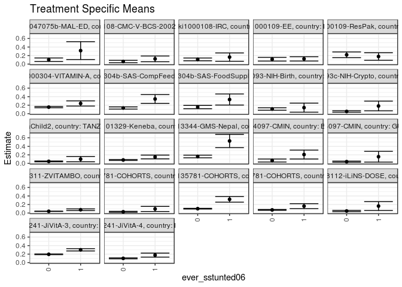

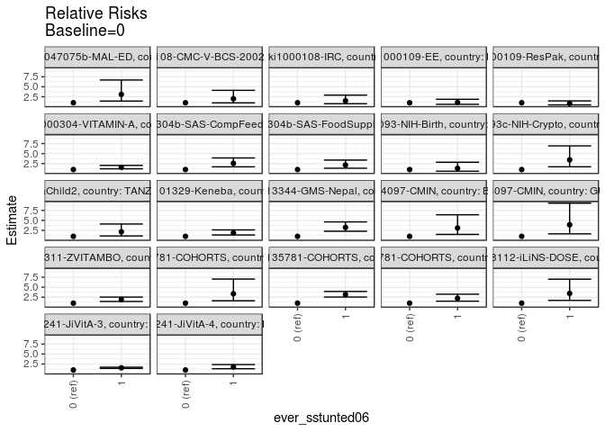

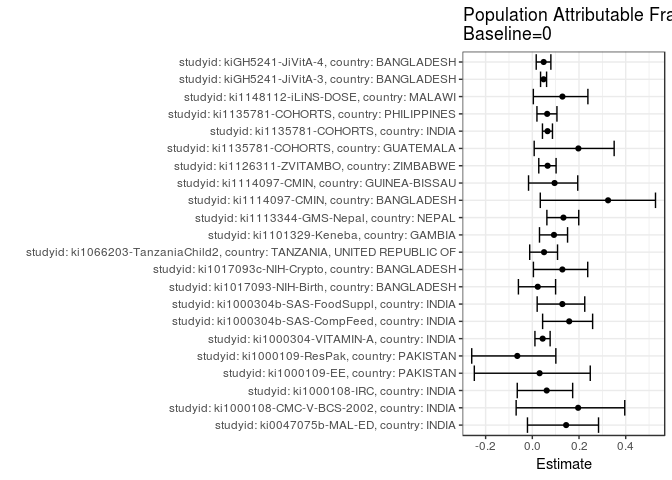

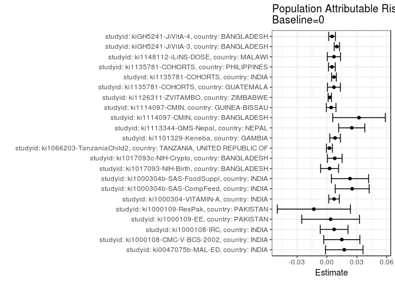

## Results Table

### Parameter: TSM

| studyid | country | intervention_level | baseline_level | estimate | ci_lower | ci_upper |
| --- | --- | --- | --- | --- | --- | --- |
| ki0047075b-MAL-ED | INDIA | 0 | NA | 0.1023256 | 0.0617270 | 0.1429241 |
| ki0047075b-MAL-ED | INDIA | 1 | NA | 0.3157895 | 0.1063324 | 0.5252465 |
| ki1000108-CMC-V-BCS-2002 | INDIA | 0 | NA | 0.0611511 | 0.0329467 | 0.0893555 |
| ki1000108-CMC-V-BCS-2002 | INDIA | 1 | NA | 0.1222222 | 0.0544604 | 0.1899840 |
| ki1000108-IRC | INDIA | 0 | NA | 0.1098592 | 0.0772896 | 0.1424287 |
| ki1000108-IRC | INDIA | 1 | NA | 0.1636364 | 0.0657472 | 0.2615255 |
| ki1000109-EE | PAKISTAN | 0 | NA | 0.1142857 | 0.0711969 | 0.1573745 |
| ki1000109-EE | PAKISTAN | 1 | NA | 0.1226994 | 0.0722643 | 0.1731345 |
| ki1000109-ResPak | PAKISTAN | 0 | NA | 0.2176871 | 0.1508242 | 0.2845500 |
| ki1000109-ResPak | PAKISTAN | 1 | NA | 0.1780822 | 0.0901191 | 0.2660453 |
| ki1000304-VITAMIN-A | INDIA | 0 | NA | 0.1545756 | 0.1391440 | 0.1700073 |
| ki1000304-VITAMIN-A | INDIA | 1 | NA | 0.2408377 | 0.1801843 | 0.3014911 |
| ki1000304b-SAS-CompFeed | INDIA | 0 | NA | 0.1350211 | 0.1091022 | 0.1609400 |
| ki1000304b-SAS-CompFeed | INDIA | 1 | NA | 0.3456790 | 0.2421003 | 0.4492577 |
| ki1000304b-SAS-FoodSuppl | INDIA | 0 | NA | 0.1568047 | 0.1179904 | 0.1956191 |
| ki1000304b-SAS-FoodSuppl | INDIA | 1 | NA | 0.3333333 | 0.2037898 | 0.4628769 |
| ki1017093-NIH-Birth | BANGLADESH | 0 | NA | 0.1106383 | 0.0822515 | 0.1390250 |
| ki1017093-NIH-Birth | BANGLADESH | 1 | NA | 0.1428571 | 0.0369255 | 0.2487888 |
| ki1017093c-NIH-Crypto | BANGLADESH | 0 | NA | 0.0530973 | 0.0362076 | 0.0699871 |
| ki1017093c-NIH-Crypto | BANGLADESH | 1 | NA | 0.1818182 | 0.0677758 | 0.2958606 |
| ki1066203-TanzaniaChild2 | TANZANIA, UNITED REPUBLIC OF | 0 | NA | 0.0469432 | 0.0372550 | 0.0566315 |
| ki1066203-TanzaniaChild2 | TANZANIA, UNITED REPUBLIC OF | 1 | NA | 0.1000000 | 0.0380044 | 0.1619956 |
| ki1101329-Keneba | GAMBIA | 0 | NA | 0.0797514 | 0.0676655 | 0.0918373 |
| ki1101329-Keneba | GAMBIA | 1 | NA | 0.1501976 | 0.1061647 | 0.1942306 |
| ki1113344-GMS-Nepal | NEPAL | 0 | NA | 0.1617647 | 0.1307944 | 0.1927350 |
| ki1113344-GMS-Nepal | NEPAL | 1 | NA | 0.5250000 | 0.3701124 | 0.6798876 |
| ki1114097-CMIN | BANGLADESH | 0 | NA | 0.0670103 | 0.0317554 | 0.1022652 |
| ki1114097-CMIN | BANGLADESH | 1 | NA | 0.2068966 | 0.1024392 | 0.3113539 |
| ki1114097-CMIN | GUINEA-BISSAU | 0 | NA | 0.0400943 | 0.0268828 | 0.0533059 |
| ki1114097-CMIN | GUINEA-BISSAU | 1 | NA | 0.1562500 | 0.0303757 | 0.2821243 |
| ki1126311-ZVITAMBO | ZIMBABWE | 0 | NA | 0.0404889 | 0.0361296 | 0.0448483 |
| ki1126311-ZVITAMBO | ZIMBABWE | 1 | NA | 0.0769231 | 0.0566386 | 0.0972076 |
| ki1135781-COHORTS | GUATEMALA | 0 | NA | 0.0285714 | 0.0170564 | 0.0400864 |
| ki1135781-COHORTS | GUATEMALA | 1 | NA | 0.0957447 | 0.0362294 | 0.1552600 |
| ki1135781-COHORTS | INDIA | 0 | NA | 0.1016860 | 0.0938351 | 0.1095369 |
| ki1135781-COHORTS | INDIA | 1 | NA | 0.3210526 | 0.2546608 | 0.3874444 |
| ki1135781-COHORTS | PHILIPPINES | 0 | NA | 0.0730488 | 0.0630467 | 0.0830509 |
| ki1135781-COHORTS | PHILIPPINES | 1 | NA | 0.1612903 | 0.1033780 | 0.2192027 |
| ki1148112-iLiNS-DOSE | MALAWI | 0 | NA | 0.0474308 | 0.0322996 | 0.0625621 |
| ki1148112-iLiNS-DOSE | MALAWI | 1 | NA | 0.1632653 | 0.0597130 | 0.2668176 |
| kiGH5241-JiVitA-3 | BANGLADESH | 0 | NA | 0.1960115 | 0.1881669 | 0.2038561 |
| kiGH5241-JiVitA-3 | BANGLADESH | 1 | NA | 0.3013393 | 0.2747524 | 0.3279262 |
| kiGH5241-JiVitA-4 | BANGLADESH | 0 | NA | 0.1007256 | 0.0896746 | 0.1117766 |
| kiGH5241-JiVitA-4 | BANGLADESH | 1 | NA | 0.1769912 | 0.1299716 | 0.2240107 |

### Parameter: E(Y)

| studyid | country | intervention_level | baseline_level | estimate | ci_lower | ci_upper |
| --- | --- | --- | --- | --- | --- | --- |
| ki0047075b-MAL-ED | INDIA | NA | NA | 0.1196581 | 0.0779840 | 0.1613323 |
| ki1000108-CMC-V-BCS-2002 | INDIA | NA | NA | 0.0760870 | 0.0489610 | 0.1032130 |
| ki1000108-IRC | INDIA | NA | NA | 0.1170732 | 0.0859146 | 0.1482317 |
| ki1000109-EE | PAKISTAN | NA | NA | 0.1179625 | 0.0851837 | 0.1507412 |
| ki1000109-ResPak | PAKISTAN | NA | NA | 0.2045455 | 0.1511224 | 0.2579685 |
| ki1000304-VITAMIN-A | INDIA | NA | NA | 0.1617391 | 0.1466878 | 0.1767905 |
| ki1000304b-SAS-CompFeed | INDIA | NA | NA | 0.1603563 | 0.1395035 | 0.1812092 |
| ki1000304b-SAS-FoodSuppl | INDIA | NA | NA | 0.1799486 | 0.1417254 | 0.2181718 |
| ki1017093-NIH-Birth | BANGLADESH | NA | NA | 0.1132813 | 0.0858017 | 0.1407608 |
| ki1017093c-NIH-Crypto | BANGLADESH | NA | NA | 0.0609418 | 0.0434802 | 0.0784034 |
| ki1066203-TanzaniaChild2 | TANZANIA, UNITED REPUBLIC OF | NA | NA | 0.0494277 | 0.0397346 | 0.0591208 |
| ki1101329-Keneba | GAMBIA | NA | NA | 0.0879121 | 0.0760335 | 0.0997906 |
| ki1113344-GMS-Nepal | NEPAL | NA | NA | 0.1866438 | 0.1550166 | 0.2182711 |
| ki1114097-CMIN | BANGLADESH | NA | NA | 0.0992063 | 0.0622241 | 0.1361886 |
| ki1114097-CMIN | GUINEA-BISSAU | NA | NA | 0.0443182 | 0.0307131 | 0.0579233 |
| ki1126311-ZVITAMBO | ZIMBABWE | NA | NA | 0.0433251 | 0.0390011 | 0.0476491 |
| ki1135781-COHORTS | GUATEMALA | NA | NA | 0.0355951 | 0.0234770 | 0.0477132 |
| ki1135781-COHORTS | INDIA | NA | NA | 0.1087695 | 0.1008135 | 0.1167256 |
| ki1135781-COHORTS | PHILIPPINES | NA | NA | 0.0780116 | 0.0679971 | 0.0880261 |
| ki1148112-iLiNS-DOSE | MALAWI | NA | NA | 0.0544554 | 0.0387997 | 0.0701112 |
| kiGH5241-JiVitA-3 | BANGLADESH | NA | NA | 0.2059588 | 0.1983834 | 0.2135343 |
| kiGH5241-JiVitA-4 | BANGLADESH | NA | NA | 0.1058706 | 0.0951082 | 0.1166331 |

### Parameter: RR

| studyid | country | intervention_level | baseline_level | estimate | ci_lower | ci_upper |
| --- | --- | --- | --- | --- | --- | --- |
| ki0047075b-MAL-ED | INDIA | 0 | 0 | 1.0000000 | 1.0000000 | 1.000000 |
| ki0047075b-MAL-ED | INDIA | 1 | 0 | 3.0861244 | 1.4247928 | 6.684596 |
| ki1000108-CMC-V-BCS-2002 | INDIA | 0 | 0 | 1.0000000 | 1.0000000 | 1.000000 |
| ki1000108-CMC-V-BCS-2002 | INDIA | 1 | 0 | 1.9986928 | 0.9717187 | 4.111039 |
| ki1000108-IRC | INDIA | 0 | 0 | 1.0000000 | 1.0000000 | 1.000000 |
| ki1000108-IRC | INDIA | 1 | 0 | 1.4895105 | 0.7639928 | 2.904009 |
| ki1000109-EE | PAKISTAN | 0 | 0 | 1.0000000 | 1.0000000 | 1.000000 |
| ki1000109-EE | PAKISTAN | 1 | 0 | 1.0736196 | 0.6146301 | 1.875371 |
| ki1000109-ResPak | PAKISTAN | 0 | 0 | 1.0000000 | 1.0000000 | 1.000000 |
| ki1000109-ResPak | PAKISTAN | 1 | 0 | 0.8180651 | 0.4572748 | 1.463519 |
| ki1000304-VITAMIN-A | INDIA | 0 | 0 | 1.0000000 | 1.0000000 | 1.000000 |
| ki1000304-VITAMIN-A | INDIA | 1 | 0 | 1.5580574 | 1.1883084 | 2.042856 |
| ki1000304b-SAS-CompFeed | INDIA | 0 | 0 | 1.0000000 | 1.0000000 | 1.000000 |
| ki1000304b-SAS-CompFeed | INDIA | 1 | 0 | 2.5601852 | 1.6796826 | 3.902254 |
| ki1000304b-SAS-FoodSuppl | INDIA | 0 | 0 | 1.0000000 | 1.0000000 | 1.000000 |
| ki1000304b-SAS-FoodSuppl | INDIA | 1 | 0 | 2.1257862 | 1.3409450 | 3.369987 |
| ki1017093-NIH-Birth | BANGLADESH | 0 | 0 | 1.0000000 | 1.0000000 | 1.000000 |
| ki1017093-NIH-Birth | BANGLADESH | 1 | 0 | 1.2912088 | 0.5891491 | 2.829878 |
| ki1017093c-NIH-Crypto | BANGLADESH | 0 | 0 | 1.0000000 | 1.0000000 | 1.000000 |
| ki1017093c-NIH-Crypto | BANGLADESH | 1 | 0 | 3.4242424 | 1.6948601 | 6.918232 |
| ki1066203-TanzaniaChild2 | TANZANIA, UNITED REPUBLIC OF | 0 | 0 | 1.0000000 | 1.0000000 | 1.000000 |
| ki1066203-TanzaniaChild2 | TANZANIA, UNITED REPUBLIC OF | 1 | 0 | 2.1302325 | 1.1082977 | 4.094469 |
| ki1101329-Keneba | GAMBIA | 0 | 0 | 1.0000000 | 1.0000000 | 1.000000 |
| ki1101329-Keneba | GAMBIA | 1 | 0 | 1.8833222 | 1.3539395 | 2.619690 |
| ki1113344-GMS-Nepal | NEPAL | 0 | 0 | 1.0000000 | 1.0000000 | 1.000000 |
| ki1113344-GMS-Nepal | NEPAL | 1 | 0 | 3.2454545 | 2.2831469 | 4.613359 |
| ki1114097-CMIN | BANGLADESH | 0 | 0 | 1.0000000 | 1.0000000 | 1.000000 |
| ki1114097-CMIN | BANGLADESH | 1 | 0 | 3.0875332 | 1.4891393 | 6.401591 |
| ki1114097-CMIN | GUINEA-BISSAU | 0 | 0 | 1.0000000 | 1.0000000 | 1.000000 |
| ki1114097-CMIN | GUINEA-BISSAU | 1 | 0 | 3.8970588 | 1.6320588 | 9.305466 |
| ki1126311-ZVITAMBO | ZIMBABWE | 0 | 0 | 1.0000000 | 1.0000000 | 1.000000 |
| ki1126311-ZVITAMBO | ZIMBABWE | 1 | 0 | 1.8998549 | 1.4289583 | 2.525930 |
| ki1135781-COHORTS | GUATEMALA | 0 | 0 | 1.0000000 | 1.0000000 | 1.000000 |
| ki1135781-COHORTS | GUATEMALA | 1 | 0 | 3.3510638 | 1.5975218 | 7.029406 |
| ki1135781-COHORTS | INDIA | 0 | 0 | 1.0000000 | 1.0000000 | 1.000000 |
| ki1135781-COHORTS | INDIA | 1 | 0 | 3.1572948 | 2.5319218 | 3.937132 |
| ki1135781-COHORTS | PHILIPPINES | 0 | 0 | 1.0000000 | 1.0000000 | 1.000000 |
| ki1135781-COHORTS | PHILIPPINES | 1 | 0 | 2.2079796 | 1.5035062 | 3.242537 |
| ki1148112-iLiNS-DOSE | MALAWI | 0 | 0 | 1.0000000 | 1.0000000 | 1.000000 |
| ki1148112-iLiNS-DOSE | MALAWI | 1 | 0 | 3.4421768 | 1.6923798 | 7.001136 |
| kiGH5241-JiVitA-3 | BANGLADESH | 0 | 0 | 1.0000000 | 1.0000000 | 1.000000 |
| kiGH5241-JiVitA-3 | BANGLADESH | 1 | 0 | 1.5373553 | 1.3960344 | 1.692982 |
| kiGH5241-JiVitA-4 | BANGLADESH | 0 | 0 | 1.0000000 | 1.0000000 | 1.000000 |
| kiGH5241-JiVitA-4 | BANGLADESH | 1 | 0 | 1.7571621 | 1.3156923 | 2.346763 |

### Parameter: PAR

| studyid | country | intervention_level | baseline_level | estimate | ci_lower | ci_upper |
| --- | --- | --- | --- | --- | --- | --- |
| ki0047075b-MAL-ED | INDIA | 0 | NA | 0.0173325 | -0.0015396 | 0.0362047 |
| ki1000108-CMC-V-BCS-2002 | INDIA | 0 | NA | 0.0149359 | -0.0032143 | 0.0330861 |
| ki1000108-IRC | INDIA | 0 | NA | 0.0072140 | -0.0067387 | 0.0211668 |
| ki1000109-EE | PAKISTAN | 0 | NA | 0.0036768 | -0.0253146 | 0.0326681 |
| ki1000109-ResPak | PAKISTAN | 0 | NA | -0.0131416 | -0.0498875 | 0.0236042 |
| ki1000304-VITAMIN-A | INDIA | 0 | NA | 0.0071635 | 0.0018759 | 0.0124511 |
| ki1000304b-SAS-CompFeed | INDIA | 0 | NA | 0.0253353 | 0.0082748 | 0.0423957 |
| ki1000304b-SAS-FoodSuppl | INDIA | 0 | NA | 0.0231439 | 0.0044491 | 0.0418386 |
| ki1017093-NIH-Birth | BANGLADESH | 0 | NA | 0.0026430 | -0.0063859 | 0.0116718 |
| ki1017093c-NIH-Crypto | BANGLADESH | 0 | NA | 0.0078445 | 0.0004679 | 0.0152210 |
| ki1066203-TanzaniaChild2 | TANZANIA, UNITED REPUBLIC OF | 0 | NA | 0.0024844 | -0.0004963 | 0.0054652 |
| ki1101329-Keneba | GAMBIA | 0 | NA | 0.0081607 | 0.0027872 | 0.0135341 |
| ki1113344-GMS-Nepal | NEPAL | 0 | NA | 0.0248791 | 0.0117447 | 0.0380135 |
| ki1114097-CMIN | BANGLADESH | 0 | NA | 0.0321960 | 0.0057970 | 0.0585951 |
| ki1114097-CMIN | GUINEA-BISSAU | 0 | NA | 0.0042238 | -0.0005978 | 0.0090455 |
| ki1126311-ZVITAMBO | ZIMBABWE | 0 | NA | 0.0028362 | 0.0012079 | 0.0044645 |
| ki1135781-COHORTS | GUATEMALA | 0 | NA | 0.0070237 | 0.0005443 | 0.0135030 |
| ki1135781-COHORTS | INDIA | 0 | NA | 0.0070836 | 0.0047082 | 0.0094589 |
| ki1135781-COHORTS | PHILIPPINES | 0 | NA | 0.0049628 | 0.0015715 | 0.0083541 |
| ki1148112-iLiNS-DOSE | MALAWI | 0 | NA | 0.0070246 | 0.0003977 | 0.0136515 |
| kiGH5241-JiVitA-3 | BANGLADESH | 0 | NA | 0.0099473 | 0.0072921 | 0.0126026 |
| kiGH5241-JiVitA-4 | BANGLADESH | 0 | NA | 0.0051451 | 0.0018322 | 0.0084580 |

### Parameter: PAF

| studyid | country | intervention_level | baseline_level | estimate | ci_lower | ci_upper |
| --- | --- | --- | --- | --- | --- | --- |
| ki0047075b-MAL-ED | INDIA | 0 | NA | 0.1448505 | -0.0207766 | 0.2836036 |
| ki1000108-CMC-V-BCS-2002 | INDIA | 0 | NA | 0.1963001 | -0.0692768 | 0.3959155 |
| ki1000108-IRC | INDIA | 0 | NA | 0.0616197 | -0.0644938 | 0.1727922 |
| ki1000109-EE | PAKISTAN | 0 | NA | 0.0311688 | -0.2484373 | 0.2481530 |
| ki1000109-ResPak | PAKISTAN | 0 | NA | -0.0642479 | -0.2595267 | 0.1007545 |
| ki1000304-VITAMIN-A | INDIA | 0 | NA | 0.0442905 | 0.0112026 | 0.0762711 |
| ki1000304b-SAS-CompFeed | INDIA | 0 | NA | 0.1579934 | 0.0441117 | 0.2583076 |
| ki1000304b-SAS-FoodSuppl | INDIA | 0 | NA | 0.1286137 | 0.0208009 | 0.2245560 |
| ki1017093-NIH-Birth | BANGLADESH | 0 | NA | 0.0233309 | -0.0595512 | 0.0997296 |
| ki1017093c-NIH-Crypto | BANGLADESH | 0 | NA | 0.1287208 | 0.0046998 | 0.2372880 |
| ki1066203-TanzaniaChild2 | TANZANIA, UNITED REPUBLIC OF | 0 | NA | 0.0502643 | -0.0112177 | 0.1080082 |
| ki1101329-Keneba | GAMBIA | 0 | NA | 0.0928276 | 0.0307440 | 0.1509345 |
| ki1113344-GMS-Nepal | NEPAL | 0 | NA | 0.1332974 | 0.0623927 | 0.1988400 |
| ki1114097-CMIN | BANGLADESH | 0 | NA | 0.3245361 | 0.0341363 | 0.5276233 |
| ki1114097-CMIN | GUINEA-BISSAU | 0 | NA | 0.0953072 | -0.0161749 | 0.1945588 |
| ki1126311-ZVITAMBO | ZIMBABWE | 0 | NA | 0.0654630 | 0.0276576 | 0.1017985 |
| ki1135781-COHORTS | GUATEMALA | 0 | NA | 0.1973214 | 0.0080165 | 0.3505004 |
| ki1135781-COHORTS | INDIA | 0 | NA | 0.0651245 | 0.0434433 | 0.0863143 |
| ki1135781-COHORTS | PHILIPPINES | 0 | NA | 0.0636160 | 0.0198001 | 0.1054732 |
| ki1148112-iLiNS-DOSE | MALAWI | 0 | NA | 0.1289975 | 0.0043477 | 0.2380419 |
| kiGH5241-JiVitA-3 | BANGLADESH | 0 | NA | 0.0482977 | 0.0353237 | 0.0610973 |
| kiGH5241-JiVitA-4 | BANGLADESH | 0 | NA | 0.0485978 | 0.0167177 | 0.0794443 |